# Expedia Hotel Recommendation

Anandan Balaji

7 June 2016

# 1 Introduction

The objective of **Expedia Hotel Recommendation** is to predict the **hotel cluster** for the user. The hotel clusters are numbered based on many parameters like distance for the city center, amenities like swimming pool, gym etc. They are in the range 1 to 100.

# 2 Deep Dive into Dataset

## 2.1 Data Files

The following are the data files provided.

- **train.csv** - the training dataset
- **test.csv** - the test dataset
- **destinations.csv** - hotel search latent attributes
- **sample_submission.csv** - the sample submission file in the correct format

## 2.2 Important Fields in the dataset

The following are the important fields which are available in the **training** dataset.

- **date_time** - TimeStamp
- `user location info`
  - **posa_continent** - ID of the continent
  - **user_location_contry** - ID of the country where the customer is located
  - **user_location_region** - ID of the region where the customer is located
  - **user_location_city** - ID of the city where the customer is located
- **orig_destination_distance** - Physical distance between the hotel and customer at the time of search
- `stay information`
  - **srch_ci** - Checkin date
  - **srch_co** - Checkout date
  - **srch_adults_cnt** - Number of adults
  - **srch_childrens_cnt** - Number of childrens
  - **srch_rm_cnt** - Number of rooms requested in the search
- `destination hotel info`
  - **srch_destination_id** - ID of the destination hotel
  - **hotel_continent** - Hotel continent
  - **hotel_country** - Hotel Country
- **is_booking** - 1 if a booking, 0 if a click.
- **cnt** - Number of similar events in the context of same user session.
- **hotel_cluster** - ID of the hotel cluster

Also the **destinations.csv** has the following information.

- **srch_destination_id** - ID of the destination hotel
- **d1-d149** - latent description of search regions

## 2.3 Submission File

For every user event, we need to predict a space-delimited list of the hotel clusters they booked. we may submit up to 5 predictions for each user event. The file should contain a header and have the following format:

id,hotel_cluster 0,99 3 1 75 20 1,2 50 30 23 9 etc…

## 2.4 Limitations of the Dataset

# 3 Exploring the data

## 3.1 Downsampling the training dataset

The **training** dataset has 37M records with 4GB in size. we can’t load the complete training datset in a normal computer. Need a better machine with atleast 16GB RAM size.

The following are some ways to deal with big data set.

- **sample the training data** - Use CATools package to create a smaller dataset by sampling as below. Note that the sampling will help in the early explorations. But for **final analysis and prediction, we have to run the complete training and test dataset**.

```r
# for splitting the training data
library(caTools)

system.time(train_dt <- fread("train.csv", header = TRUE))

#to make it reproducible
set.seed(123)

## specify the column name
split = sample.split(train_dt$hotel_cluster, SplitRatio = 0.75)

new_train_dt = subset(train_dt, split == TRUE)
new_test_dt  = subset(train_dt, split == FALSE)

write.csv(new_train_dt, file = "new_train.csv", row.names = FALSE, quote = FALSE)
write.csv(new_test_dt, file = "new_test.csv", row.names = TRUE, quote = FALSE)
```

- **Use fread()** - The fread() from `data.table` package is faster than the read.csv() function.

[output not shown]

[output not shown]

## 3.2 Examine the Date info

Let’s take a look at the date info in the **training** dataset.

```r
train_dt$year <- as.numeric(format(as.Date(train_dt$date_time, "%Y-%m-%d"), "%Y"))
unique(train_dt$year)
```

```
## [1] 2014 2013
```

Examine the records in the **test** data.

```r
test_dt$year <- as.numeric(format(as.Date(test_dt$date_time, "%Y-%m-%d"), "%Y"))
unique(test_dt$year)
```

```
## [1] 2015
```

## 3.3 Does the destination id specified in the **test** data present in the training data?

```r
# get the size of the destination id list for test data
test_dest_list_len <- length(unique(test_dt$srch_destination_id))
test_dest_list_len
```

```
## [1] 40718
```

```r
intersect_list_len <- length(intersect(test_dt$srch_destination_id, train_dt$srch_destination_id))
intersect_list_len
```

```
## [1] 34392
```

```r
test_dest_list_len == intersect_list_len
```

```
## [1] FALSE
```

## 3.4 Charts

### 3.4.1 The user’s current location and the destination hotel location

The posa_continent is user current location at the time of booking and the hotel_continent is the desitnation location.

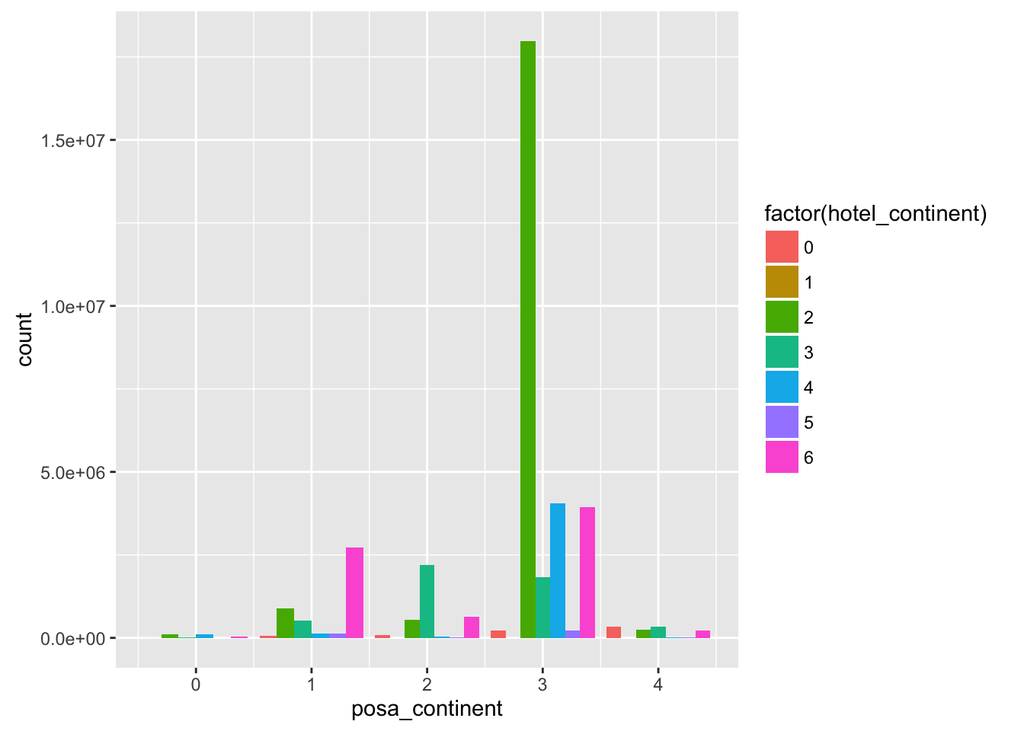

```r
ggplot(train_dt, aes(posa_continent, fill = factor(hotel_continent))) + geom_bar(position = "dodge")
```

```r
# ggplot(train_dt,
#        aes(x = hotel_cluster, y = hotel_continent, col = factor(hotel_continent))) +       # to avoid over plotting
#   geom_jitter(alpha = 0.7) +
#       geom_smooth(method = "lm", se = F)
```

# 4 Approach to solution

## 4.1 Correlation Info of hotel_cluster with rest of attributes.

```r
cor(train_dt$hotel_cluster, train_dt$srch_destination_id)
```

```
## [1] -0.0117117
```

```r
cor(train_dt$hotel_cluster, train_dt$posa_continent)
```

```
## [1] 0.01493817
```

```r
cor(train_dt$hotel_cluster, train_dt$user_location_country)
```

```
## [1] -0.0104773
```

```r
cor(train_dt$hotel_cluster, train_dt$user_location_region)
```

```
## [1] 0.007453461
```

```r
cor(train_dt$hotel_cluster, train_dt$user_location_city)
```

```
## [1] 0.0008305327
```

```r
cor(train_dt$hotel_cluster, train_dt$orig_destination_distance)
```

```
## [1] NA
```

```r
cor(train_dt$hotel_cluster, train_dt$user_id)
```

```
## [1] 0.001051576
```

```r
cor(train_dt$hotel_cluster, train_dt$is_package)
```

```
## [1] 0.03873255
```

```r
#cor(train_dt$hotel_cluster, train_dt$srch_ci)
#cor(train_dt$hotel_cluster, train_dt$srch_co)
cor(train_dt$hotel_cluster, train_dt$srch_adults_cnt)
```

```
## [1] 0.01230921
```

```r
cor(train_dt$hotel_cluster, train_dt$srch_children_cnt)
```

```
## [1] 0.01626055
```

```r
cor(train_dt$hotel_cluster, train_dt$srch_rm_cnt)
```

```
## [1] -0.005954061
```

```r
cor(train_dt$hotel_cluster, train_dt$srch_destination_id)
```

```
## [1] -0.0117117
```

```r
cor(train_dt$hotel_cluster, train_dt$srch_destination_type_id)
```

```
## [1] -0.03284968
```

```r
cor(train_dt$hotel_cluster, train_dt$is_booking)
```

```
## [1] -0.02154807
```

```r
cor(train_dt$hotel_cluster, train_dt$cnt)
```

```
## [1] 0.002943866
```

```r
cor(train_dt$hotel_cluster, train_dt$hotel_continent)
```

```
## [1] -0.0139633
```

```r
cor(train_dt$hotel_cluster, train_dt$hotel_country)
```

```
## [1] -0.02428855
```

```r
cor(train_dt$hotel_cluster, train_dt$hotel_market)
```

```
## [1] 0.03420536
```

## 4.2 Linear Model

```r
model = lm(hotel_cluster ~ srch_destination_id + srch_destination_type_id + is_booking + cnt + orig_destination_distance + user_location_country + user_location_region + is_mobile + is_package + hotel_continent + hotel_country + hotel_market, data= train_dt)
summary(model)
```

```
##
## Call:
## lm(formula = hotel_cluster ~ srch_destination_id + srch_destination_type_id +
##     is_booking + cnt + orig_destination_distance + user_location_country +
##     user_location_region + is_mobile + is_package + hotel_continent +
##     hotel_country + hotel_market, data = train_dt)
##
## Residuals:
##     Min      1Q  Median      3Q     Max
## -56.824 -25.049  -0.745  24.135  59.321
##
## Coefficients:
##                             Estimate Std. Error t value Pr(>|t|)
## (Intercept)                5.044e+01  2.582e-02 1953.74   <2e-16 ***
## srch_destination_id        1.328e-05  6.228e-07   21.32   <2e-16 ***
## srch_destination_type_id  -4.024e-01  3.122e-03 -128.90   <2e-16 ***
## is_booking                -2.204e+00  2.176e-02 -101.29   <2e-16 ***
## cnt                       -1.223e-01  5.038e-03  -24.28   <2e-16 ***
## orig_destination_distance  1.782e-04  3.000e-06   59.41   <2e-16 ***
## user_location_country     -6.395e-03  1.119e-04  -57.17   <2e-16 ***
## user_location_region       1.201e-03  4.142e-05   28.99   <2e-16 ***
## is_mobile                  3.383e-01  1.727e-02   19.59   <2e-16 ***
## is_package                 2.663e+00  1.451e-02  183.57   <2e-16 ***
## hotel_continent           -7.113e-02  4.543e-03  -15.66   <2e-16 ***
## hotel_country             -1.269e-02  1.208e-04 -105.09   <2e-16 ***
## hotel_market               1.574e-03  1.265e-05  124.45   <2e-16 ***
## ---
## Signif. codes:  0 '***' 0.001 '**' 0.01 '*' 0.05 '.' 0.1 ' ' 1
##
## Residual standard error: 29.06 on 24145279 degrees of freedom
##   (13525001 observations deleted due to missingness)
## Multiple R-squared:  0.005001,   Adjusted R-squared:  0.005
## F-statistic: 1.011e+04 on 12 and 24145279 DF,  p-value: < 2.2e-16
```

```r
#to avoid multi colinearity, try different model
model2 = lm(hotel_cluster ~ srch_destination_id + cnt + orig_destination_distance + user_location_region + hotel_country + hotel_market, data=train_dt)
summary(model2)
```

```
##
## Call:
## lm(formula = hotel_cluster ~ srch_destination_id + cnt + orig_destination_distance +
##     user_location_region + hotel_country + hotel_market, data = train_dt)
##
## Residuals:
##     Min      1Q  Median      3Q     Max
## -54.978 -24.817  -0.908  24.102  54.284
##
## Coefficients:
##                             Estimate Std. Error t value Pr(>|t|)
## (Intercept)                4.971e+01  2.051e-02 2423.91   <2e-16 ***
## srch_destination_id       -4.160e-05  5.535e-07  -75.16   <2e-16 ***
## cnt                        5.580e-02  4.978e-03   11.21   <2e-16 ***
## orig_destination_distance  2.033e-04  2.791e-06   72.84   <2e-16 ***
## user_location_region       1.336e-03  4.143e-05   32.24   <2e-16 ***
## hotel_country             -1.550e-02  1.148e-04 -134.99   <2e-16 ***
## hotel_market               1.680e-03  1.261e-05  133.28   <2e-16 ***
## ---
## Signif. codes:  0 '***' 0.001 '**' 0.01 '*' 0.05 '.' 0.1 ' ' 1
##
## Residual standard error: 29.11 on 24145285 degrees of freedom
##   (13525001 observations deleted due to missingness)
## Multiple R-squared:  0.001746,   Adjusted R-squared:  0.001745
## F-statistic:  7037 on 6 and 24145285 DF,  p-value: < 2.2e-16
```

## 4.3 Non Linear Model

```r
# library(rpart)
# frmla = hotel_cluster ~ srch_destination_id + user_location_region + orig_destination_distance
# ctrl = rpart.control(minSplit=5, minbucket = 50)
#
# expediaTreeModel = rpart(frmla, data = train_dt, method = "class", control=ctrl )
#
# # get the cp - complexity factor
# printcp(expediaTreeModel)
#summary(expediaTreeModel)
```